# SI 618 - Homework #2: More Data Manipulation

### Q3. [10 points] Item Analysis

1. What is the average item-unit price?
2. What % of items are under $25?
3. Generate a histogram of the unit prices. Select reasonable min/max values for the x-axis. Why did you pick those values? What do you notice about the histogram?

|  | StockCode | Description | UnitPrice |
| --- | --- | --- | --- |
| 1041 | 21134 | None | 0.0 |
| 1042 | 22145 | None | 0.0 |
| 1043 | 37509 | None | 0.0 |
| 1047 | 85226A | None | 0.0 |
| 1048 | 85044 | None | 0.0 |
| ... | ... | ... | ... |
| 4015 | 79323LP | Unsaleable, destroyed. | 0.0 |
| 4016 | 79323S | Unsaleable, destroyed. | 0.0 |
| 4017 | 79341 | Unsaleable, destroyed. | 0.0 |
| 4018 | 79342B | Unsaleable, destroyed. | 0.0 |
| 4050 | 84971L | None | 0.0 |

215 rows × 3 columns

```
Average Unit Price for the items: 7.290397146562905
Percentage items with unit price less than $25: 98.67704280155642%
```

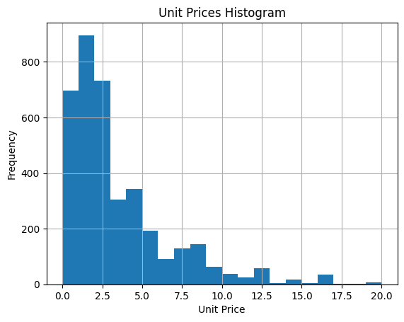

```python
## Question 3.1
## Checking for 0 or negative values
display(items[items['UnitPrice'] <= 0])

## Removing items with price = 0
items_with_price = items[items['UnitPrice'] > 0]
print(f"Average Unit Price for the items: {items_with_price['UnitPrice'].mean()}")

## Question 3.2
items_under_25 = items_with_price[items_with_price['UnitPrice'] < 25]
percentage_items_under_25 = (len(items_under_25)/len(items_with_price)) * 100
print(f"Percentage items with unit price less than $25: {percentage_items_under_25}%")

## Question 3.3
_ = items_with_price.hist(range=[0, 20], bins=20)
plt.title('Unit Prices Histogram')
plt.xlabel('Unit Price')
plt.ylabel('Frequency')
plt.show()
```

### Q4. [25 points] Order Trends

1. What are the top 10 most ordered items? Describe them. Do you see any trends?
2. What are the top 5 invoices that generated the most revenue? (Revenue is calculated by "marking up" the unit price by 25%.)
3. Do the top 5 invoices contain any of the top 10 most ordered items?

*Hint: When calculating the revenue we suggest adding a new column on the dataframe.*

```python
## Question 4.1
## Removing any negative or zero values
purchases_positive = purchases[purchases['Quantity'] > 0]
item_counts = purchases_positive.groupby(by='StockCodeSC').sum(numeric_only=True)
top_ten_items = item_counts.sort_values(by='Quantity', ascending=False).head(10)
print('Top 10 most ordered items')
display(top_ten_items)

## Question 4.2
# Removing the "SC" that is added at the start of the stock codes
purchases_positive['StockCodeSC'] = purchases_positive['StockCodeSC'].str[2:]

# ## Calculating marked up price
items['MarkedUpPrice'] = items['UnitPrice']* 1.25

## Merging both datasets
merged_data = pd.merge(purchases_positive, items.rename(columns={'StockCode':'StockCodeSC'}), 'left', 'StockCodeSC')
merged_data['revenue'] = merged_data['MarkedUpPrice'] * merged_data['Quantity']

## Getting the top 5 invoices
top_revenue_invoices = merged_data.groupby('InvoiceNo').sum().sort_values(by='revenue', ascending=False)
top_revenue_invoices = top_revenue_invoices.drop(columns=['Quantity', 'UnitPrice', 'MarkedUpPrice']).head(5)

print('Top 5 invoices by revenue generated:')
display(top_revenue_invoices)

## Question 4.3
## Getting the invoice numbers from top invoices
invoice_nos = top_revenue_invoices.index.to_list()

## Getting the required invoices and stock codes
required_invoices = merged_data[merged_data['InvoiceNo'].isin(invoice_nos)]
required_stock_codes = top_ten_items.index.str[2:].to_list()

## Checking if the stock codes are in the top invoices
stock_codes = required_invoices[required_invoices['StockCodeSC'].isin(required_stock_codes)]['StockCodeSC']

print(f"Stock codes {stock_codes.values.tolist()} are in the top 5 invoices")
```

```
Top 10 most ordered items
```

| StockCodeSC | Quantity |
| --- | --- |
| SC23843 | 80995 |
| SC23166 | 78033 |
| SC22197 | 56921 |
| SC84077 | 55047 |
| SC85099B | 48478 |
| SC85123A | 41664 |
| SC84879 | 36461 |
| SC21212 | 36419 |
| SC23084 | 31722 |
| SC22492 | 26633 |

```
Top 5 invoices by revenue generated:
```

| InvoiceNo | revenue |
| --- | --- |
| 547966 | 712212.5000 |
| 581483 | 210587.0000 |
| 541431 | 96479.5000 |
| 556255 | 37305.0000 |
| 556917 | 34545.9125 |

```
Stock codes ['23166', '23166', '23084', '85099B', '22492', '21212', '23843'] are in the top 5 invoices
```